# Chapter 1 Plots

Jim Albert

June 8, 2017

### Plotting a Career Trajectory

#### Writing a Plot Trajectory Function

Here is some insight how `plot_hr_trajectory` works:

1. The input is the player’s full name in quotes.
2. Using the `Master` data frame in the `Lahman` package, I find the `playerID` and birth information for that player.
3. From the `Batting` data frame of hitting data, I collect `HR`, `AB` for all seasons of the player’s career.
4. I find the `Age` variable by first finding the player’s birthyear, adjusting the birthyear depending on the birthmonth, and then defining `Age`.
5. I use `ggplot2` to construct a scatterplot and smoothing curve for the home run rate `HR` / `AB`.

```r
plot_hr_trajectory <- function(playername){
  require(Lahman)
  require(dplyr)
  require(stringr)
  require(ggplot2)
  names <- unlist(str_split(playername, " "))
  info <- filter(Master, nameLast==names[2],
                       nameFirst==names[1])

  bdata <- filter(Batting, playerID==info$playerID)
  bdata <- mutate(bdata,
          birthyear = ifelse(info$birthMonth >= 7,
                  info$birthYear + 1, info$birthYear),
          Age = yearID - birthyear)

  ggplot(bdata, aes(yearID, HR / AB)) +
    geom_point() +
    geom_smooth(method="loess", se=FALSE)
}
```

#### Plotting Two Trajectories

I illustrate using this function for two players. Note that I am saving the `ggplot2` plotting object in a variable. By just typing the variable name, I see the graph.

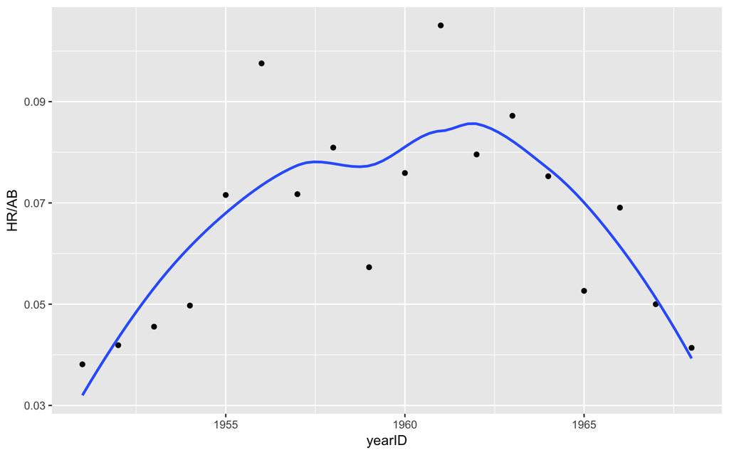

```r
p1 <- plot_hr_trajectory("Mickey Mantle")
p1
```

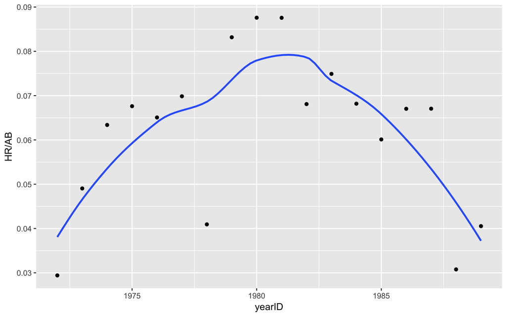

```r
p2 <- plot_hr_trajectory("Mike Schmidt")
p2
```

#### Comparing Trajectories

The `ggplot2` object contains the plotting data. So I combine the data from the two earlier plotting objects to construct a graph that compares the two trajectories.

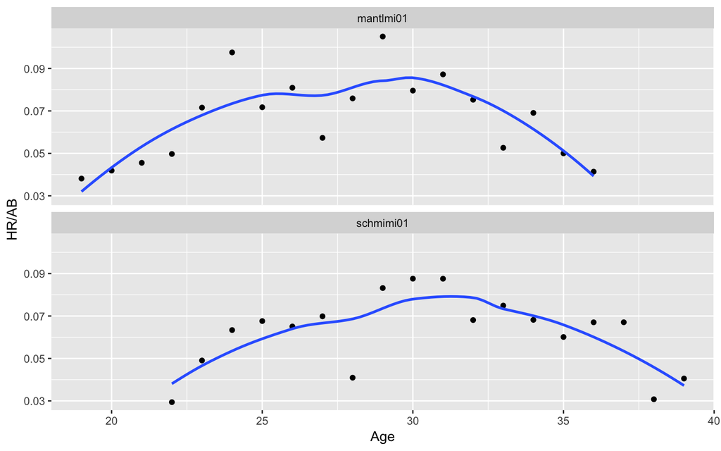

```r
ggplot(rbind(p1$data, p2$data), aes(Age, HR / AB)) +
  geom_point() +
  geom_smooth(method="loess", se=FALSE) +
  facet_wrap(~ playerID, ncol=1)
```